# Toddler Uncertainty Signals

Emily

2017-09-13

Data analysis of toddler uncertainty signals study.

Preliminaries.

# 1 Eyetracker task

Filter unfamiliar trials (parents reported that child did not know word), and kids who performed below chance. Two participants dropped for below-chance performance (109 and 70).

```r
rm(list=ls())
load("data_et.RData")

#identify chance performers
mss_et_acc <-  d_et
mss_et_acc$acc <- as.numeric(as.character(mss_et_acc$acc))
mss_et_acc <- mss_et_acc %>%
  group_by(ID)%>%
  summarise(acc = mean(acc))%>%
  mutate(drop_acc = acc < .5)

drop_acc <- mss_et_acc$ID[mss_et_acc$drop_acc == TRUE]

#remove unfamiliar trials.
#remove trials with zero fixations to AOIs.
#remove participants who performed at chance.
d_et_filt<- d_et%>%
  dplyr::filter(!ID %in% drop_acc,
                familiarity != 0,
                fixations != 0)

#compare trials with 0 and >0 fixations.
d_et_filt_comp <- d_et%>%
  dplyr::filter(!ID %in% drop_acc,
                familiarity != 0)%>%
  mutate(looked = fixations != 0)

#how many trials are missing due to 0 fixations?

nofix <- filter(d_et_filt_comp, looked == FALSE)
length(nofix$ID)
```

```
## [1] 196
```

```r
length(unique(nofix$ID))
```

```
## [1] 38
```

```r
#any difference in accuracy based on whether there were any fixations to AOIs?
t.test(d_et_filt_comp$acc[d_et_filt_comp$fixations == 0], d_et_filt_comp$acc[d_et_filt_comp$fixations != 0])
```

```
##
##  Welch Two Sample t-test
##
## data:  d_et_filt_comp$acc[d_et_filt_comp$fixations == 0] and d_et_filt_comp$acc[d_et_filt_comp$fixations != 0]
## t = 1.2924, df = 283.13, p-value = 0.1973
## alternative hypothesis: true difference in means is not equal to 0
## 95 percent confidence interval:
##  -0.01863057  0.08986695
## sample estimates:
## mean of x mean of y
## 0.8571429 0.8215247
```

```r
d_et_filt_comp <- d_et_filt_comp%>%
  group_by(looked)%>%
  multi_boot_standard(col="acc")
```

## 1.1 Accuracy

Get a dataframe for looking at accuracy by similarity.

```r
mss_et_acc_tt <-  d_et_filt
mss_et_acc_tt$acc <- as.numeric(as.character(mss_et_acc_tt$acc))

#get mean accuracy by similarity condition.
mss_et_acc_t <- mss_et_acc_tt %>%
  group_by(ID, similar)%>%
  summarise(acc = mean(acc))%>%
  spread(similar, acc)

mss_et_acc_r <- mss_et_acc_tt %>%
  group_by(ID)%>%
  summarise(acc = mean(acc))

accet <- describeBy(mss_et_acc_r$acc)
accet$mean
```

```
## [1] 0.818029
```

```r
accet$sd
```

```
## [1] 0.1197208
```

```r
accet$min
```

```
## [1] 0.5
```

```r
accet$max
```

```
## [1] 1
```

T-test for effect of similarity on accuracy.

```r
t.test(mss_et_acc_t$similar,
       mss_et_acc_t$dissimilar, paired = TRUE)
```

```
##
##  Paired t-test
##
## data:  mss_et_acc_t$similar and mss_et_acc_t$dissimilar
## t = -4.5165, df = 67, p-value = 2.616e-05
## alternative hypothesis: true difference in means is not equal to 0
## 95 percent confidence interval:
##  -0.14876321 -0.05757433
## sample estimates:
## mean of the differences
##              -0.1031688
```

```r
similar <- psych::describe(mss_et_acc_t$similar)
dissimilar <- psych::describe(mss_et_acc_t$dissimilar)

similar
```

```
##    vars  n mean   sd median trimmed mad  min max range skew kurtosis   se
## X1    1 69 0.77 0.18    0.8    0.78 0.2 0.33   1  0.67 -0.4    -0.62 0.02
```

```r
dissimilar
```

```
##    vars  n mean   sd median trimmed  mad  min max range  skew kurtosis
## X1    1 68 0.87 0.12    0.9    0.89 0.15 0.57   1  0.43 -0.67     -0.4
##      se
## X1 0.01
```

```r
#get effect size
cohensd_acc <- abs((similar$mean - dissimilar$mean)/((similar$sd + dissimilar$sd)/2))
cohensd_acc
```

```
## [1] 0.73311
```

## 1.2 Switches

Set up a dataframe with switches averaged by accuracy and similiarity within participants.

```r
mss_et_acc <-  d_et_filt %>%  #filter(d_et_filt, !is.na(first_fix)) to exclude trials with no fixations
  mutate(acc = ifelse(acc == 1, "acc", "inacc"))

#get average gaze switches for three conditions: accurate-similar, accurate-dissimilar, and inaccurate.
mss_et_inacc <-  mss_et_acc%>%
  group_by(ID, acc)%>%
  summarise(trans = mean(trans))%>%
  spread(acc, trans)%>%
  select(-acc)

mss_et_acc <-  mss_et_acc%>%
  group_by(ID, acc)%>%
  summarise(trans = mean(trans))%>%
  spread(acc, trans)

mss_et_sim <-  d_et_filt %>%
  dplyr::group_by(ID, acc, similar)%>%
  dplyr::summarise(trans = mean(trans))%>%
  dplyr::filter(acc == 1)%>%
  tidyr::spread(similar, trans)%>%
  dplyr::mutate(similar_acc = similar)%>%
  dplyr::mutate(dissimilar_acc = dissimilar)

mss_et_aov <- mss_et_inacc %>%
  left_join(mss_et_sim)%>%
  dplyr::filter(!is.na(similar_acc),
         !is.na(dissimilar_acc),
         !is.na(inacc))%>%
  gather("trial_type", "trans", inacc:dissimilar_acc) %>%
  filter(trial_type != "acc",
         trial_type != "similar",
         trial_type != "dissimilar")
```

### 1.2.1 Repeated measures ANOVA

Repeated-measures ANOVA with trial type (similar and accurate, dissimilar and accurate, and inaccurate) as the independent variable.

```r
ET.aov <- with(mss_et_aov,
                   aov(trans ~ trial_type +
                       Error(ID /trial_type))) #add error term for ID for repeated measures
summary(ET.aov)
```

```
##
## Error: ID
##           Df Sum Sq Mean Sq F value Pr(>F)
## Residuals 59  69.37   1.176
##
## Error: ID:trial_type
##             Df Sum Sq Mean Sq F value Pr(>F)
## trial_type   2   5.34  2.6721   4.683  0.011 *
## Residuals  118  67.33  0.5706
## ---
## Signif. codes:  0 '***' 0.001 '**' 0.01 '*' 0.05 '.' 0.1 ' ' 1
```

```r
ezANOVA(
mss_et_aov
, trans
, ID
, within = trial_type
, within_full = NULL
, within_covariates = NULL
, between = NULL
, between_covariates = NULL
, observed = NULL
, diff = NULL
, reverse_diff = FALSE
, type = 2
, white.adjust = FALSE
, detailed = FALSE
, return_aov = FALSE
)
```

```
## $ANOVA
##       Effect DFn DFd        F          p p<.05        ges
## 2 trial_type   2 118 4.683396 0.01103372     * 0.03762514
##
## $`Mauchly's Test for Sphericity`
##       Effect         W            p p<.05
## 2 trial_type 0.6752392 1.133111e-05     *
##
## $`Sphericity Corrections`
##       Effect       GGe      p[GG] p[GG]<.05       HFe     p[HF] p[HF]<.05
## 2 trial_type 0.7548533 0.01931019         * 0.7704117 0.0186349         *
```

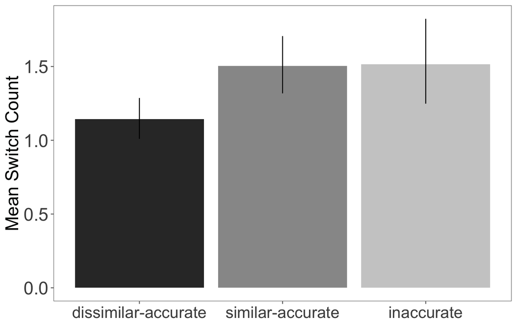

```r
#get means and CIs for plot.
mss_et_aov_p <- mss_et_aov %>%
  group_by(trial_type)%>%
  multi_boot_standard(col = "trans", na.rm = TRUE)

mss_et_aov_p$trial_type <- factor(mss_et_aov_p$trial_type,
                            levels = c("dissimilar_acc","similar_acc","inacc"))

mss_et_aov_p$trial_type <- factor(mss_et_aov_p$trial_type,
levels = c("dissimilar_acc", "similar_acc", "inacc"),
labels = c("dissimilar-accurate", "similar-accurate", "inaccurate"))

ggplot(mss_et_aov_p, aes(trial_type, mean, fill = trial_type)) + geom_bar(stat = "identity") +
  geom_linerange(aes(ymin = ci_lower, ymax = ci_upper),
             position = position_dodge(width = .9)) +
  ylab("Mean Switch Count")  +
  theme(panel.grid = element_blank()) + #no gridlines
  scale_fill_grey() + #grayscale
  ggthemes::theme_few() +
  theme(legend.position='none',
        axis.text.x  = element_text(vjust=0.5, size=18),
        axis.title.x = element_blank(),
        axis.text.y  = element_text(vjust=0.5, size=20),
        axis.title.y = element_text(size=20))
```

### 1.2.2 T-tests

```r
t.test(subset(mss_et_aov, trial_type=="inacc")$trans,
       subset(mss_et_aov, trial_type=="similar_acc")$trans, paired = TRUE)
```

```
##
##  Paired t-test
##
## data:  subset(mss_et_aov, trial_type == "inacc")$trans and subset(mss_et_aov, trial_type == "similar_acc")$trans
## t = 0.065232, df = 59, p-value = 0.9482
## alternative hypothesis: true difference in means is not equal to 0
## 95 percent confidence interval:
##  -0.3146127  0.3358164
## sample estimates:
## mean of the differences
##              0.01060185
```

```r
t.test(subset(mss_et_aov, trial_type=="inacc")$trans,
       subset(mss_et_aov, trial_type=="dissimilar_acc")$trans, paired = TRUE)
```

```
##
##  Paired t-test
##
## data:  subset(mss_et_aov, trial_type == "inacc")$trans and subset(mss_et_aov, trial_type == "dissimilar_acc")$trans
## t = 2.4891, df = 59, p-value = 0.01565
## alternative hypothesis: true difference in means is not equal to 0
## 95 percent confidence interval:
##  0.07269359 0.66872175
## sample estimates:
## mean of the differences
##               0.3707077
```

```r
t.test(subset(mss_et_aov, trial_type=="similar_acc")$trans,
       subset(mss_et_aov, trial_type=="dissimilar_acc")$trans, paired = TRUE)
```

```
##
##  Paired t-test
##
## data:  subset(mss_et_aov, trial_type == "similar_acc")$trans and subset(mss_et_aov, trial_type == "dissimilar_acc")$trans
## t = 3.9152, df = 59, p-value = 0.0002368
## alternative hypothesis: true difference in means is not equal to 0
## 95 percent confidence interval:
##  0.1760632 0.5441485
## sample estimates:
## mean of the differences
##               0.3601058
```

```r
#get effect sizes
inacc_et <- psych::describe(subset(mss_et_aov, trial_type=="inacc")$trans)
sim_acc_et <- psych::describe(subset(mss_et_aov, trial_type=="similar_acc")$trans)
dissim_acc_et <- psych::describe(subset(mss_et_aov, trial_type=="dissimilar_acc")$trans)

cohensd_inacc_sim_acc_et <- abs((inacc_et$mean - sim_acc_et$mean)/((inacc_et$sd + sim_acc_et$sd)/2))
cohensd_inacc_sim_acc_et
```

```
## [1] 0.01078371
```

```r
cohensd_inacc_dissim_acc_et <- abs((inacc_et$mean - dissim_acc_et$mean)/((inacc_et$sd + dissim_acc_et$sd)/2))
cohensd_inacc_dissim_acc_et
```

```
## [1] 0.4288623
```

```r
cohensd_sim_acc_dissim_acc_et <- abs((sim_acc_et$mean - dissim_acc_et$mean)/((sim_acc_et$sd + dissim_acc_et$sd)/2))
cohensd_sim_acc_dissim_acc_et
```

```
## [1] 0.528104
```

Do the number of transitions differ based on whether the correct one was fixated first? No.

```r
mss_et_ff <-  filter(d_et_filt, !is.na(first_fix))%>%
  group_by(ID, first_fix)%>%
  summarise(trans = mean(trans))%>%
  spread(first_fix, trans)%>%
  filter(!is.na(correct) & !is.na(incorrect))

t.test(mss_et_ff$correct, mss_et_ff$incorrect, paired = TRUE)
```

```
##
##  Paired t-test
##
## data:  mss_et_ff$correct and mss_et_ff$incorrect
## t = -1.4349, df = 67, p-value = 0.156
## alternative hypothesis: true difference in means is not equal to 0
## 95 percent confidence interval:
##  -0.31538986  0.05157729
## sample estimates:
## mean of the differences
##              -0.1319063
```

```r
mss_et_d <-  filter(d_et_filt, !is.na(first_fix))%>%
  group_by(ID, first_fix)%>%
  summarise(trans = mean(trans))

describeBy(mss_et_d$trans, mss_et_d$first_fix)
```

```
## $correct
##    vars  n mean   sd median trimmed  mad min max range skew kurtosis  se
## X1    1 68 1.28 0.81   1.16    1.22 0.62   0   5     5 1.45     4.52 0.1
##
## $incorrect
##    vars  n mean   sd median trimmed  mad min  max range skew kurtosis   se
## X1    1 69 1.41 0.55   1.33    1.41 0.56   0 2.88  2.88 0.19     0.25 0.07
##
## attr(,"call")
## by.default(data = x, INDICES = group, FUN = describe, type = type)
```

Based on trial type?

```r
mss_trans_acc <-  d_et_filt %>%
  mutate(acc = ifelse(acc == 1, "acc", "inacc"))%>%
  filter(!is.na(first_fix))

#get average gaze switches for three conditions: accurate-similar, accurate-dissimilar, and inaccurate.
mss_trans_inacc <-  mss_trans_acc%>%
  filter(!is.na(first_fix))%>%
  group_by(ID, acc, first_fix)%>%
  summarise(trans = mean(trans))%>%
  spread(acc, trans)%>%
  select(-acc)%>%
  spread(first_fix, inacc)%>%
  filter(!is.na(correct), !is.na(incorrect))%>%
  gather("first_fix", "inacc", correct:incorrect)

mss_trans_sim <-  d_et_filt %>%
  group_by(ID, acc, similar, first_fix)%>%
  summarise(trans = mean(trans))%>%
  filter(acc == 1, !is.na(first_fix))%>%
  spread(similar, trans)%>%
  mutate(similar_acc = similar)%>%
  mutate(dissimilar_acc = dissimilar)%>%
  select(-similar, -dissimilar)

mss_trans_sim_acc <- mss_trans_sim %>%
  select(-dissimilar_acc)%>%
  spread(first_fix, similar_acc)%>%
  filter(!is.na(correct), !is.na(incorrect))%>%
  gather("first_fix", "similar_acc", correct:incorrect)

mss_trans_dissim_acc <- mss_trans_sim %>%
  select(-similar_acc)%>%
  spread(first_fix, dissimilar_acc)%>%
  filter(!is.na(correct), !is.na(incorrect))%>%
  gather("first_fix", "dissimilar_acc", correct:incorrect)

mss_trans_aov <- mss_trans_inacc %>%
  inner_join(mss_trans_sim_acc)%>%
  select(-acc)%>%
  inner_join(mss_trans_dissim_acc)%>%
  select(-acc)%>%
  gather("trial_type", "trans", inacc:dissimilar_acc)
```

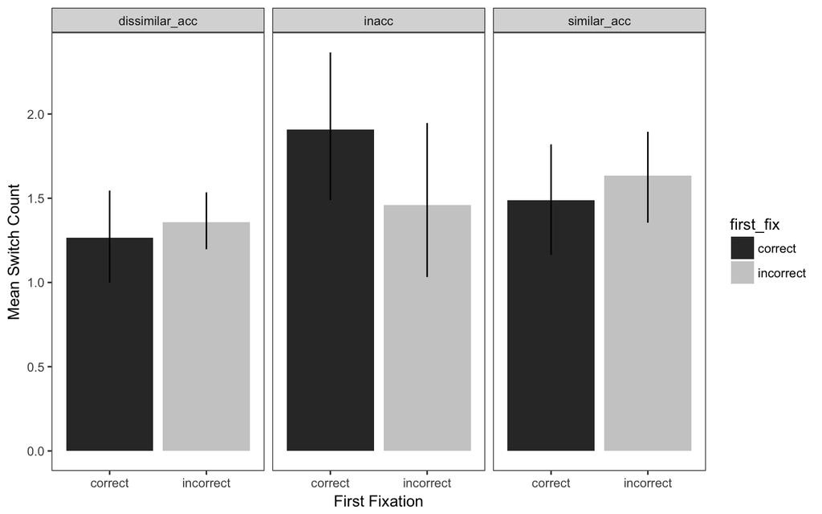

```r
mss_trans_aov_p <- mss_trans_aov %>%
  group_by(first_fix, trial_type)%>%
  multi_boot_standard(col = "trans", na.rm = TRUE)

ggplot(mss_trans_aov_p, aes(x = factor(first_fix), y = mean, fill = first_fix)) + geom_bar(stat = "identity") +
  geom_linerange(aes(ymin = ci_lower, ymax = ci_upper),
             position = position_dodge(width = .9)) +
  xlab("First Fixation") +
  ylab("Mean Switch Count")  +
  facet_grid(~trial_type) +
  theme(panel.grid = element_blank()) + #no gridlines
  scale_fill_grey() #grayscale
```

```r
library(car)
Anova(lm(trans ~ first_fix * trial_type, data=mss_trans_aov), type=3)
```

```
## Anova Table (Type III tests)
##
## Response: trans
##                       Sum Sq  Df F value    Pr(>F)
## (Intercept)           49.696   1 51.5685 1.759e-11 ***
## first_fix              0.129   1  0.1337   0.71507
## trial_type             6.597   2  3.4228   0.03476 *
## first_fix:trial_type   3.342   2  1.7340   0.17951
## Residuals            173.462 180
## ---
## Signif. codes:  0 '***' 0.001 '**' 0.01 '*' 0.05 '.' 0.1 ' ' 1
```

```r
summary(lm(trans ~ first_fix * trial_type, data=mss_trans_aov))
```

```
##
## Call:
## lm(formula = trans ~ first_fix * trial_type, data = mss_trans_aov)
##
## Residuals:
##     Min      1Q  Median      3Q     Max
## -1.9086 -0.6339 -0.1559  0.5403  4.5403
##
## Coefficients:
##                                          Estimate Std. Error t value
## (Intercept)                               1.26613    0.17631   7.181
## first_fixincorrect                        0.09117    0.24934   0.366
## trial_typeinacc                           0.64247    0.24934   2.577
## trial_typesimilar_acc                     0.22312    0.24934   0.895
## first_fixincorrect:trial_typeinacc       -0.54009    0.35263  -1.532
## first_fixincorrect:trial_typesimilar_acc  0.05346    0.35263   0.152
##                                          Pr(>|t|)
## (Intercept)                              1.76e-11 ***
## first_fixincorrect                         0.7151
## trial_typeinacc                            0.0108 *
## trial_typesimilar_acc                      0.3721
## first_fixincorrect:trial_typeinacc         0.1274
## first_fixincorrect:trial_typesimilar_acc   0.8797
## ---
## Signif. codes:  0 '***' 0.001 '**' 0.01 '*' 0.05 '.' 0.1 ' ' 1
##
## Residual standard error: 0.9817 on 180 degrees of freedom
## Multiple R-squared:  0.04432,    Adjusted R-squared:  0.01777
## F-statistic: 1.669 on 5 and 180 DF,  p-value: 0.1442
```

# 2 Touchscreen task

filter fast and slow RTs, missing data, unfamiliar trials, and kids who performed below chance. Two participants dropped for chance performance (70 and 89).

```r
load("data_ts.RData")

#filter fast and slow RTs, missing data, and unfamiliar trials.
top_bound <- mean(log(d_ts$RT)) + 3*sd(log(d_ts$RT))
bottom_bound <- mean(log(d_ts$RT)) - 3*sd(log(d_ts$RT))

d_filt_rt <- d_ts %>%
  dplyr::filter(log(RT) < top_bound,
         log(RT) > bottom_bound,
         familiarity != 0)

#remove participants who performed below chance.
mss_ts_acc <-  d_filt_rt
mss_ts_acc$acc <- as.numeric(as.character(mss_ts_acc$acc))
mss_ts_acc <- mss_ts_acc %>%
  group_by(ID)%>%
  summarise(acc = mean(acc))%>%
  mutate(drop_acc = acc < .5)

drop_acc_ts <- mss_ts_acc$ID[mss_ts_acc$drop_acc == TRUE]

d_filt_rt <- d_filt_rt %>%
  dplyr::filter(!ID %in% drop_acc_ts)
```

## 2.1 Accuracy

Get a dataframe for looking at accuracy by similarity.

```r
mss_ts_acc_tt <-  d_filt_rt%>%
  group_by(ID, similar)

mss_ts_acc_tt$acc <- as.numeric(as.character(mss_ts_acc_tt$acc))

mss_ts_acc_t <- mss_ts_acc_tt %>%
  summarise(acc = mean(acc))%>%
  spread(similar, acc)

mss_ts_acc_r <- mss_ts_acc_tt %>%
  group_by(ID)%>%
  summarise(acc = mean(acc))

accts <- describeBy(mss_ts_acc_r$acc)
accts$mean
```

```
## [1] 0.7793548
```

```r
accts$sd
```

```
## [1] 0.1304892
```

```r
accts$min
```

```
## [1] 0.5
```

```r
accts$max
```

```
## [1] 0.95
```

T-test for effect of similarity on accuracy.

```r
t.test(mss_ts_acc_t$similar,
       mss_ts_acc_t$dissimilar, paired = TRUE)
```

```
##
##  Paired t-test
##
## data:  mss_ts_acc_t$similar and mss_ts_acc_t$dissimilar
## t = -7.1675, df = 70, p-value = 6.178e-10
## alternative hypothesis: true difference in means is not equal to 0
## 95 percent confidence interval:
##  -0.17142088 -0.09678838
## sample estimates:
## mean of the differences
##              -0.1341046
```

```r
similar <- psych::describe(mss_ts_acc_t$similar)
dissimilar <- psych::describe(mss_ts_acc_t$dissimilar)
similar
```

```
##    vars  n mean   sd median trimmed  mad min max range  skew kurtosis   se
## X1    1 71 0.71 0.17   0.75    0.72 0.22 0.4 0.9   0.5 -0.45    -1.13 0.02
```

```r
dissimilar
```

```
##    vars  n mean   sd median trimmed  mad  min max range  skew kurtosis
## X1    1 71 0.85 0.14   0.89    0.86 0.16 0.43   1  0.57 -0.73    -0.21
##      se
## X1 0.02
```

```r
#get effect size.
cohensd_acc <- abs((similar$mean - dissimilar$mean)/((similar$sd + dissimilar$sd)/2))
cohensd_acc
```

```
## [1] 0.8777602
```

## 2.2 RTs

Set up a dataframe with RTs averaged by accuracy and similiarity within participants.

```r
mss_ts_acc <-  d_filt_rt

mss_ts_acc <- mss_ts_acc %>%
  mutate(acc = ifelse(acc == 1, "acc", "inacc"))

#get average RTs for three conditions: accurate-similar, accurate-dissimilar, and inaccurate.
mss_ts_inacc <-  mss_ts_acc%>%
  group_by(ID, acc)%>%
  summarise(RT = mean(RT))%>%
  spread(acc, RT)%>%
  select(-acc)

mss_ts_acc <-  mss_ts_acc%>%
  group_by(ID, acc)%>%
  summarise(RT = mean(RT))%>%
  spread(acc, RT)

mss_ts_sim <-  d_filt_rt %>%
  dplyr::group_by(ID, acc, similar)%>%
  dplyr::summarise(RT = mean(RT))%>%
  dplyr::filter(acc == 1)%>%
  tidyr::spread(similar, RT)%>%
  dplyr::mutate(similar_acc = similar)%>%
  dplyr::mutate(dissimilar_acc = dissimilar)

mss_ts_aov <- mss_ts_inacc %>%
  left_join(mss_ts_sim)%>%
  dplyr::filter(!is.na(similar_acc),
         !is.na(dissimilar_acc),
         !is.na(inacc))%>%
  gather("trial_type", "RT", inacc:dissimilar_acc) %>%
  filter(trial_type != "acc",
         trial_type != "similar",
         trial_type != "dissimilar")
```

### 2.2.1 Repeated-measures ANOVA

Repeated-measures ANOVA with trial type (similar and accurate, dissimilar and accurate, and inaccurate) as the independent variable.

```r
TS.aov <- with(mss_ts_aov,
                   aov(RT ~ trial_type +
                       Error(ID /trial_type))) #add error term for ID for repeated measures
summary(TS.aov)
```

```
##
## Error: ID
##           Df    Sum Sq Mean Sq F value Pr(>F)
## Residuals 70 381085269 5444075
##
## Error: ID:trial_type
##             Df    Sum Sq  Mean Sq F value   Pr(>F)
## trial_type   2  40290557 20145279   13.68 3.75e-06 ***
## Residuals  140 206196345  1472831
## ---
## Signif. codes:  0 '***' 0.001 '**' 0.01 '*' 0.05 '.' 0.1 ' ' 1
```

```r
ezANOVA(
mss_ts_aov
, RT
, ID
, within = trial_type
, within_full = NULL
, within_covariates = NULL
, between = NULL
, between_covariates = NULL
, observed = NULL
, diff = NULL
, reverse_diff = FALSE
, type = 2
, white.adjust = FALSE
, detailed = FALSE
, return_aov = FALSE
)
```

```
## $ANOVA
##       Effect DFn DFd        F            p p<.05        ges
## 2 trial_type   2 140 13.67793 3.750577e-06     * 0.06420068
##
## $`Mauchly's Test for Sphericity`
##       Effect         W           p p<.05
## 2 trial_type 0.8189084 0.001015358     *
##
## $`Sphericity Corrections`
##       Effect       GGe        p[GG] p[GG]<.05       HFe        p[HF]
## 2 trial_type 0.8466744 1.590695e-05         * 0.8654191 1.332696e-05
##   p[HF]<.05
## 2         *
```

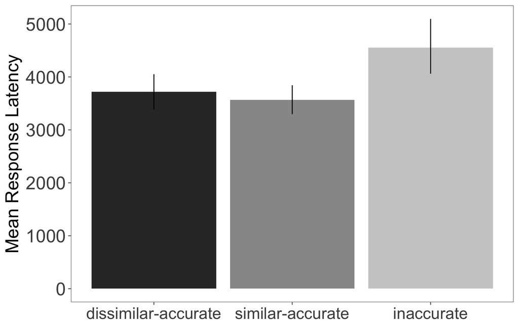

### 2.2.2 T-tests

```r
t.test(subset(mss_ts_aov, trial_type=="inacc")$RT,
       subset(mss_ts_aov, trial_type=="similar_acc")$RT, paired = TRUE)
```

```
##
##  Paired t-test
##
## data:  subset(mss_ts_aov, trial_type == "inacc")$RT and subset(mss_ts_aov, trial_type == "similar_acc")$RT
## t = 4.4631, df = 70, p-value = 3.017e-05
## alternative hypothesis: true difference in means is not equal to 0
## 95 percent confidence interval:
##   546.6119 1429.8130
## sample estimates:
## mean of the differences
##                988.2125
```

```r
t.test(subset(mss_ts_aov, trial_type=="inacc")$RT,
       subset(mss_ts_aov, trial_type=="dissimilar_acc")$RT, paired = TRUE)
```

```
##
##  Paired t-test
##
## data:  subset(mss_ts_aov, trial_type == "inacc")$RT and subset(mss_ts_aov, trial_type == "dissimilar_acc")$RT
## t = 3.6944, df = 70, p-value = 0.0004336
## alternative hypothesis: true difference in means is not equal to 0
## 95 percent confidence interval:
##   385.946 1291.573
## sample estimates:
## mean of the differences
##                838.7598
```

```r
t.test(subset(mss_ts_aov, trial_type=="similar_acc")$RT,
       subset(mss_ts_aov, trial_type=="dissimilar_acc")$RT, paired = TRUE)
```

```
##
##  Paired t-test
##
## data:  subset(mss_ts_aov, trial_type == "similar_acc")$RT and subset(mss_ts_aov, trial_type == "dissimilar_acc")$RT
## t = -0.96687, df = 70, p-value = 0.3369
## alternative hypothesis: true difference in means is not equal to 0
## 95 percent confidence interval:
##  -457.7405  158.8351
## sample estimates:
## mean of the differences
##               -149.4527
```

```r
inacc_ts <- psych::describe(subset(mss_ts_aov, trial_type=="inacc")$RT)
sim_acc_ts <- psych::describe(subset(mss_ts_aov, trial_type=="similar_acc")$RT)
dissim_acc_ts <- psych::describe(subset(mss_ts_aov, trial_type=="dissimilar_acc")$RT)

#get effect sizes.
cohensd_inacc_sim_acc_ts <- abs((inacc_ts$mean - sim_acc_ts$mean)/((inacc_ts$sd + sim_acc_ts$sd)/2))
cohensd_inacc_sim_acc_ts
```

```
## [1] 0.5932835
```

```r
cohensd_inacc_dissim_acc_ts <- abs((inacc_ts$mean - dissim_acc_ts$mean)/((inacc_ts$sd + dissim_acc_ts$sd)/2))
cohensd_inacc_dissim_acc_ts
```

```
## [1] 0.4536602
```

```r
cohensd_sim_acc_dissim_acc_ts <- abs((sim_acc_ts$mean - dissim_acc_ts$mean)/((sim_acc_ts$sd + dissim_acc_ts$sd)/2))
cohensd_sim_acc_dissim_acc_ts
```

```
## [1] 0.1113044
```

# 3 Accuracy across ET and TS tasks for plot

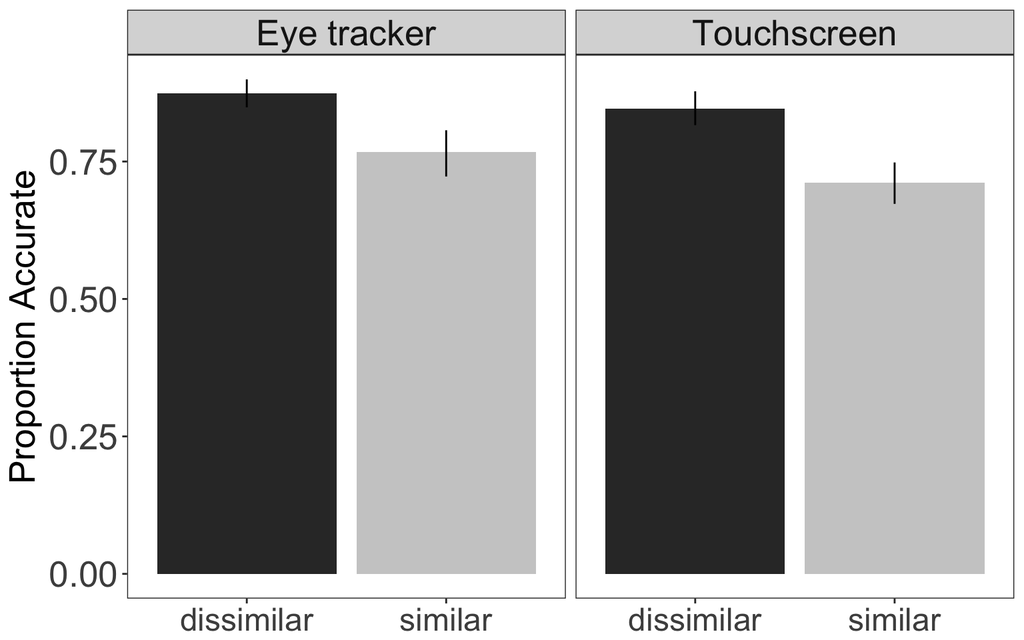

# 4 Does accuracy on a given trial in the TS task predict accuracy on the same trial in the ET task?

```r
#get matrix with trial-level accuracy for both tasks
accmat <- mss_et_acc_tt %>%
  select(ID, acc, trial)%>%
  mutate(acc_et = acc)%>%
  select(ID, trial, acc_et)%>%
  left_join(mss_ts_acc_tt)%>%
  mutate(acc_ts = acc)%>%
  select(ID, trial, acc_et, acc_ts)

summary(glmer(acc_et ~ acc_ts +
                (1|ID) +
                (1|trial), #behavior item
              data = accmat,
              family = "binomial"))
```

```
## Generalized linear mixed model fit by maximum likelihood (Laplace
##   Approximation) [glmerMod]
##  Family: binomial  ( logit )
## Formula: acc_et ~ acc_ts + (1 | ID) + (1 | trial)
##    Data: accmat
##
##      AIC      BIC   logLik deviance df.resid
##    895.7    915.2   -443.8    887.7      963
##
## Scaled residuals:
##     Min      1Q  Median      3Q     Max
## -2.9023  0.3550  0.4130  0.4665  0.7464
##
## Random effects:
##  Groups Name        Variance Std.Dev.
##  ID     (Intercept) 0.06151  0.2480
##  trial  (Intercept) 0.11243  0.3353
## Number of obs: 967, groups:  ID, 61; trial, 20
##
## Fixed effects:
##             Estimate Std. Error z value Pr(>|z|)
## (Intercept)   1.1837     0.1970   6.009 1.87e-09 ***
## acc_ts        0.5508     0.1995   2.761  0.00576 **
## ---
## Signif. codes:  0 '***' 0.001 '**' 0.01 '*' 0.05 '.' 0.1 ' ' 1
##
## Correlation of Fixed Effects:
##        (Intr)
## acc_ts -0.769
```

# 5 Correlations with age

Are the differences between condition means correlated with age in months?

```r
#Get age in months from raw data.
ids_et <- d_et%>%
  select(ID, age_months)
ids_ts <- d_ts%>%
  select(ID, age_months)

#Get dataframes with difference scores for conditions.
et_diff <- spread(mss_et_aov, trial_type, trans)%>%
  mutate(dacc_inacc = dissimilar_acc - inacc,
         sacc_inacc = similar_acc - inacc,
         dacc_sacc = dissimilar_acc - similar_acc)%>%
  left_join(ids_et)%>%
  unique

ts_diff <- spread(mss_ts_aov, trial_type, RT)%>%
  mutate(dacc_inacc = dissimilar_acc - inacc,
         sacc_inacc = similar_acc - inacc,
         dacc_sacc = dissimilar_acc - similar_acc)%>%
  left_join(ids_ts)%>%
  unique

#Get correlations of age in months with difference scores.
rcorr(et_diff$age_months, et_diff$dacc_inacc)
```

```
##      x    y
## x 1.00 0.04
## y 0.04 1.00
##
## n= 60
##
##
## P
##   x      y
## x        0.7772
## y 0.7772
```

```r
rcorr(et_diff$age_months, et_diff$sacc_inacc)
```

```
##      x    y
## x 1.00 0.05
## y 0.05 1.00
##
## n= 60
##
##
## P
##   x      y
## x        0.7211
## y 0.7211
```

```r
rcorr(et_diff$age_months, et_diff$dacc_sacc)
```

```
##       x     y
## x  1.00 -0.02
## y -0.02  1.00
##
## n= 60
##
##
## P
##   x     y
## x       0.863
## y 0.863
```

```r
rcorr(ts_diff$age_months, ts_diff$dacc_inacc)
```

```
##      x    y
## x 1.00 0.03
## y 0.03 1.00
##
## n= 71
##
##
## P
##   x      y
## x        0.7921
## y 0.7921
```

```r
rcorr(ts_diff$age_months, ts_diff$sacc_inacc)
```

```
##      x    y
## x 1.00 0.07
## y 0.07 1.00
##
## n= 71
##
##
## P
##   x      y
## x        0.5806
## y 0.5806
```

```r
rcorr(ts_diff$age_months, ts_diff$dacc_sacc)
```

```
##       x     y
## x  1.00 -0.05
## y -0.05  1.00
##
## n= 71
##
##
## P
##   x      y
## x        0.6864
## y 0.6864
```

Are the average number of switches correlated with overall accuracy?

```r
acc_et_ms <- d_et_filt%>%
  group_by(ID)%>%
  summarise(acc = mean(acc))

sw_et_ms <- d_et_filt%>%
  group_by(ID)%>%
  summarise(trans = mean(trans))

ids <- left_join(acc_et_ms, sw_et_ms)

rcorr(ids$acc, ids$trans)
```

```
##       x     y
## x  1.00 -0.07
## y -0.07  1.00
##
## n= 69
##
##
## P
##   x      y
## x        0.5624
## y 0.5624
```